## Discrete,recursive models: Revisiting SIR models

As we saw previously, SIR models are simple epidemiological compartment models that predict the spread of an infectious disease. In this example, we will use the SIR model as a way of demonstrating how to setup and simulate discrete recursive models.

#### SIR model diagram

The diagram for our model is identical to the standard SIR model that we saw previously:

```r
DiagrammeR::grViz("digraph {

# Initialize graph
graph [layout = dot, rankdir = LR]

# Define the nodes and global styles of the nodes. We can override these in box if we wish
node [shape = circle, style = filled]

#Edges in graphs must be between nodes, therefore dummy nodes are needed for signaling edges and input/output edges

OS [fixedsize = TRUE, width = 0, height = 0, label = ''] #Dummy node
S [fillcolor = green]
SI [fixedsize = TRUE, width = 0, height = 0, label = ''] #Dummy node
I [fillcolor = red]
IO [fixedsize = TRUE, width = 0, height = 0, label = ''] #Dummy node
R [fillcolor = blue]

# edge definitions with the node IDs
edge[fontsize = 10]
# Edge weights are not necessary, but can be used to get edges in straight line (higher weight edges have more emphasis)

S -> SI [label = 'rI', weight = 2, dir = none]
SI -> I [weight = 2]
I -> SI [label = '+', tailport = n, style = dashed, fontcolor = blue, color = blue]
OS -> S [label = 'rBirth', weight = 2]
I -> IO [label = 'rDeath', weight = 2]

I -> R [label = 'rR', weight = 1]
R -> S [label = 'rS', weight = 1]
}")
```

[interactive chart not shown]

#### SIR discrete model definition

Below is a function defining the discrete, recursive model, which should look similar to the function used to define the ODE SIR model. The lines defining the change in the populations are identical to those in the ODE function, but here the function is returning the new values of the populations, since it is adding the current population sizes (S,I,R) to the current change in the populations (dS,dI,dR).

```r
SIR <- function(state, parameters) {# SIR is the name of this function with state and parameters
  # with function executes lines in {} (recursive equations) using values defined in state and parameters
  with(as.list(c(state, parameters)),{
    dS <- rBirth + rS*R - rI*S*I #ODE for susceptible population
    dI <- rI*S*I - rR*I - rDeath*I #ODE for infected population
    dR <- rR*I - rS*R #ODE for recovered population

    data.frame(S=S+dS,I=I+dI,R=R+dR) #Return new value of variables
  })
}
```

#### SIR model parameters

Same as in the ODE example.

```r
parameters <- c(rBirth = 3, #Birth rate
                rDeath = 0.02, #Death rate
                rI = 0.0005, #Infection rate
                rR = 0.05, #Recovery rate
                rS = 0.01 #Loss of immunity rate
                )
```

#### SIR initial conditions

Similar to the ODE example, but here we are using the data.frame() function instead of c(). This will serve as the first row of a table showing the populations sizes over time.

```r
state <- data.frame(S = 1000, #Initial number of susceptible individuals
                    I = 10, #Initial number of infected individuals
                    R = 0 #Initial number of recovered individuals
          )
```

#### SIR discrete model simulation

For the discrete simulation we do not need a special function or algorithm. We simply use a for loop to perform the desired number of iterations by using the previous state (population sizes) as the input into our SIR function.

```r
dt <- 0.1 #Define time step
times <- seq(from = 0,to = 100, by = dt) #Definition of time (initial,final,step size)

for(i in 2:length(times)){
  state <- rbind(state,# Add new values as a row to existing table
                 SIR(state[i-1,], #Use previous row (i-1) as input into function
                     dt*parameters) #We scale parameter values by the time step
                 )
}
state <- cbind(time=times,state)
```

#### Plot simulation results

Basically the same as in the ODE example, but we are using the “type=‘b’” (b=both) argument to show both the line and discrete points.

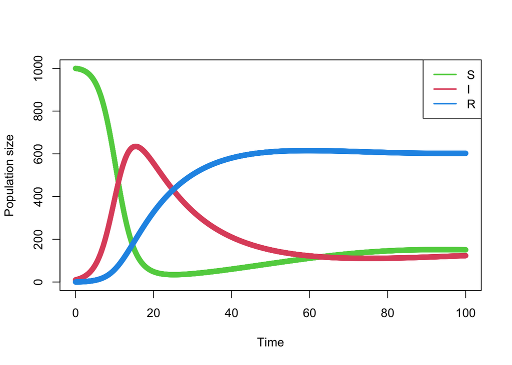

```r
plot(state[,"time"],state[,"S"],col=3,lwd=2,pch=16,type="b",xlab="Time",ylab="Population size",ylim=c(0,1000)) #Plot S population vs time
lines(state[,"time"],state[,"I"],col=2,lwd=2,pch=16,type="b") #Plot I population vs time
lines(state[,"time"],state[,"R"],col=4,lwd=2,pch=16,type="b") #Plot R population vs time
legend("topright",legend = c("S","I","R"),col = c(3,2,4),lwd = 2) #Define plot legend
```